# **CLUSTERING**

Uji Coba

Ikang Fadhli

ikanx101.com

08 November 2022

# *Introduction*

Kita akan coba lakukan *clustering* dengan beberapa metode yah, seperti:

1. *Hierarchical clustering*,
2. *K-Means clustering*, dan
3. *DBScan clustering*.

# *Workflow*

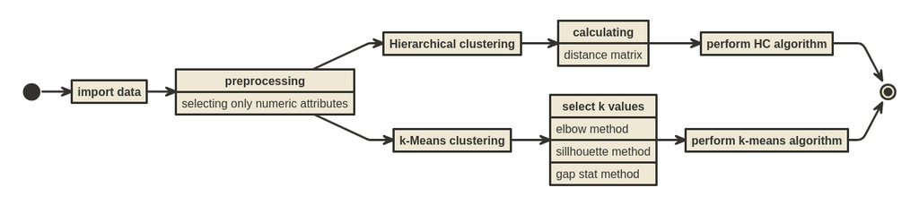

Langkah Kerja

```r
knitr::include_graphics("workflow.png")
```

# Data yang Digunakan

Berikut adalah *sample* 10 data yang akan telah terkumpul:

```r
df = read_excel("data josh.xlsx",sheet = sht[6],skip = 2) %>%
     janitor::clean_names()

head(df,10) %>% DT::datatable()
```

|  | submission_date | provinsi | kota_kabupaten | nama_toko | nama_toko_trimmed | tanggal_survey | apakah_termasuk_toko_klasifikasi_h_dan_i | apakah_termasuk_toko_distribusi_atau_special_channel | lokasi_toko | traffic_toko_jumlah_pengunjung_per_jam | apakah_toko_memiliki_chiller | apakah_toko_memiliki_freezer_ice_cream | apakah_pengunjung_mengambil_barang_sendiri_swalayan | jumlah_lorong | apakah_ada_keranjang_belanja | online_apakah_toko_memiliki_toko_online_di_marketplace | apakah_toko_merupakan_mitra | jumlah_kasir_toko | jumlah_pegawai | apakah_toko_merupakan_trader | kulakan_apakah_pembeli_membeli_barang_untuk_dijual_lagi_di_tokonya_masing_masing | dropsize_customer_rata_rata_jumlah_uang_yang_dibelanjakan_pembeli_rp_customer | produk_yang_dijual_di_toko | total |
| --- | --- | --- | --- | --- | --- | --- | --- | --- | --- | --- | --- | --- | --- | --- | --- | --- | --- | --- | --- | --- | --- | --- | --- | --- |
| 1 | Sep 10, 2022 | JAWA TENGAH | KOTA SEMARANG | 130 GANG BARU | 130 GANG BARU | Sep 10, 2022 | Tidak | Tidak | Pasar (lokasi sekitar atau dalam pasar) | 0 | 0 | 0 | 1 | 0 | 0 |  | 0 | 0 | 2 |  |  | 1 |  | 4 |
| 2 | Oct 18, 2022 | KALIMANTAN BARAT | SAMBAS | 168. TOKO | 168. TOKO | Oct 18, 2022 | Tidak | Tidak | Pasar (lokasi sekitar atau dalam pasar) | 0 | 1 | 1 | 1 | 1 | 1 |  | 0 | 1 | 3 |  |  | 1 |  | 10 |
| 3 | Oct 29, 2022 | MALUKU | KOTA TERNATE | 2 PUTRA 1 PUTRI KIOS | 2 PUTRA 1 PUTRI KIOS | Oct 29, 2022 | Tidak | Tidak | Pinggir Jalan Utama | 1 | 1 | 1 | 1 | 2 | 1 |  | 2 | 1 | 2 |  |  | 1 |  | 13 |
| 4 | Sep 21, 2022 | SUMATERA BARAT | KOTA PAYAKUMBUH | 2000 MM | 2000 MM | Sep 21, 2022 | Tidak | Tidak | Pinggir Jalan Utama | 1 | 1 | 1 | 1 | 2 | 1 |  | 0 | 1 | 3 |  |  | 1 |  | 12 |
| 5 | Sep 28, 2022 | DKI JAKARTA | KOTA JAKARTA SELATAN | 212 MART | 212 MART | Sep 28, 2020 | Tidak | Tidak | Residential (lokasi tempat tinggal/perumahan/apartemen/dsb.) | 0 | 1 | 1 | 1 | 2 | 1 |  | 0 | 2 | 2 |  |  | 1 |  | 11 |
| 6 | Oct 31, 2022 | JAWA TENGAH | KARANGANYAR | 212 MART (FIRYAL NIDA AFIFAH) | 212 MART (FIRYAL NIDA AFIFAH) | Sep 19, 2022 | Tidak | Tidak | Pinggir Jalan Utama | 0 | 1 | 0 | 1 | 1 | 1 |  | 0 | 2 | 3 |  |  | 0 |  | 9 |
| 7 | Sep 19, 2022 | JAWA BARAT | KOTA BEKASI | 212 MART AMANAM MUTAQIN | 212 MART AMANAM MUTAQIN | Sep 19, 2022 | Tidak | Tidak | Residential (lokasi tempat tinggal/perumahan/apartemen/dsb.) | 0 | 1 | 1 | 1 | 1 | 1 |  | 0 | 1 | 2 |  |  | 1 |  | 9 |
| 8 | Sep 26, 2022 | KALIMANTAN SELATAN | KOTA BANJARMASIN | 212 MART ANSARI SALEH | 212 MART ANSARI SALEH | Sep 26, 2022 | Tidak | Tidak | Pinggir Jalan Utama | 0 | 1 | 1 | 1 | 2 | 1 |  | 0 | 1 | 3 |  |  | 1 |  | 11 |
| 9 | Sep 28, 2022 | JAWA BARAT | KOTA DEPOK | 212 MART BEJI TIMUR | 212 MART BEJI TIMUR | Sep 28, 2022 | Tidak | Tidak | Pinggir Jalan Utama | 2 | 1 | 1 | 1 | 2 | 1 |  | 0 | 1 | 3 |  |  | 0 |  | 12 |
| 10 | Sep 15, 2022 | DKI JAKARTA | KOTA JAKARTA TIMUR | 212 MART DUREN SAWIT | 212 MART DUREN SAWIT | Sep 15, 2022 | Tidak | Tidak | Residential (lokasi tempat tinggal/perumahan/apartemen/dsb.) | 0 | 1 | 1 | 1 | 2 | 1 |  | 0 | 1 | 2 |  |  | 1 |  | 10 |

```r
# kita hanya akan pilih data numerik saja
df_final = df %>% select(where(is.numeric))
```

Sedangkan berikut adalah data numerik yang akan dimasukkan ke analisa *clustering*:

```r
head(df_final,10) %>% DT::datatable()
```

|  | traffic_toko_jumlah_pengunjung_per_jam | apakah_toko_memiliki_chiller | apakah_toko_memiliki_freezer_ice_cream | apakah_pengunjung_mengambil_barang_sendiri_swalayan | jumlah_lorong | apakah_ada_keranjang_belanja | apakah_toko_merupakan_mitra | jumlah_kasir_toko | jumlah_pegawai | dropsize_customer_rata_rata_jumlah_uang_yang_dibelanjakan_pembeli_rp_customer | total |
| --- | --- | --- | --- | --- | --- | --- | --- | --- | --- | --- | --- |
| 1 | 0 | 0 | 0 | 1 | 0 | 0 | 0 | 0 | 2 | 1 | 4 |
| 2 | 0 | 1 | 1 | 1 | 1 | 1 | 0 | 1 | 3 | 1 | 10 |
| 3 | 1 | 1 | 1 | 1 | 2 | 1 | 2 | 1 | 2 | 1 | 13 |
| 4 | 1 | 1 | 1 | 1 | 2 | 1 | 0 | 1 | 3 | 1 | 12 |
| 5 | 0 | 1 | 1 | 1 | 2 | 1 | 0 | 2 | 2 | 1 | 11 |
| 6 | 0 | 1 | 0 | 1 | 1 | 1 | 0 | 2 | 3 | 0 | 9 |
| 7 | 0 | 1 | 1 | 1 | 1 | 1 | 0 | 1 | 2 | 1 | 9 |
| 8 | 0 | 1 | 1 | 1 | 2 | 1 | 0 | 1 | 3 | 1 | 11 |
| 9 | 2 | 1 | 1 | 1 | 2 | 1 | 0 | 1 | 3 | 0 | 12 |
| 10 | 0 | 1 | 1 | 1 | 2 | 1 | 0 | 1 | 2 | 1 | 10 |

## *Pairs Plot*

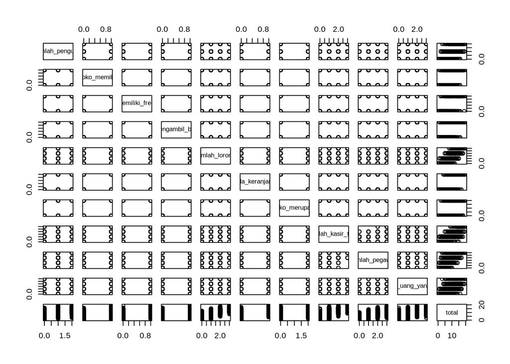

```r
pairs(df_final)
```

# *k-Means Clustering*

Pertama-tama saya akan melakukan k-means clustering, langkah awal yang harus dilakukan adalah mencari nilai $k$ yang tepat.

Saya akan gunakan tiga metode yang bisa digunakan untuk mencarinya, yakni:

1. *Elbow method*,
2. *Sillhouette method*, dan
3. *Gap Stat method*.

## *Elbow method*

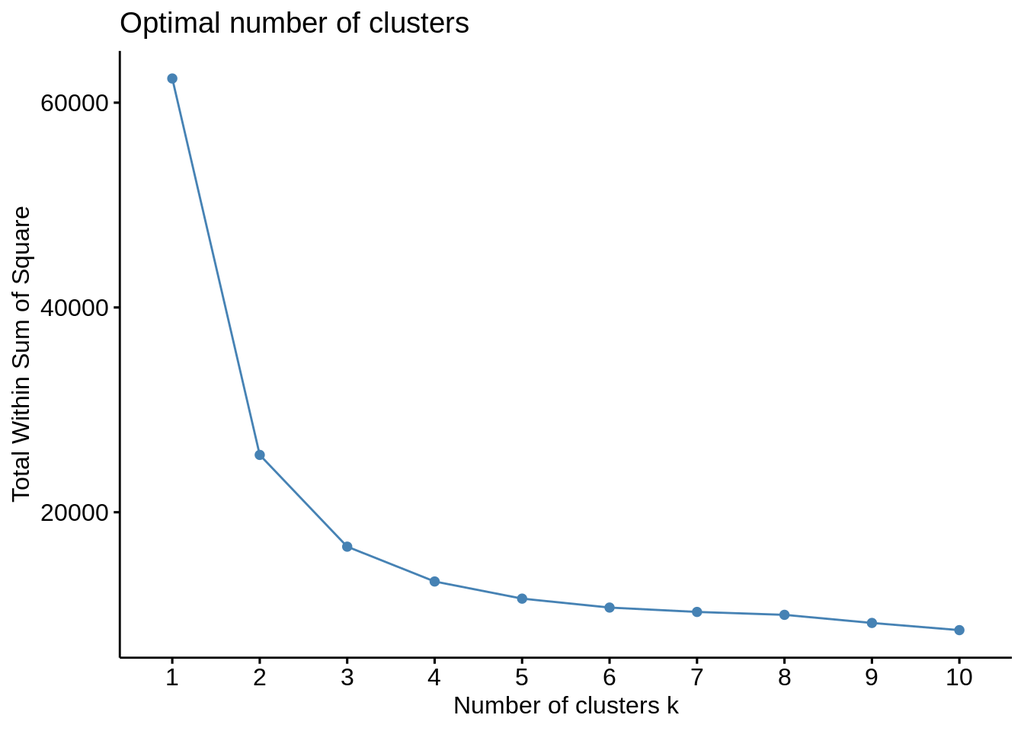

```r
# elbow method dan plotnya
elbow = fviz_nbclust(df_final, kmeans, method = "wss")
plot(elbow)
```

Dari *plot* di atas, kita dapatkan nilai $k=3$ memberikan hasil *cluster* yang optimal.

## *Sillhouette Method*

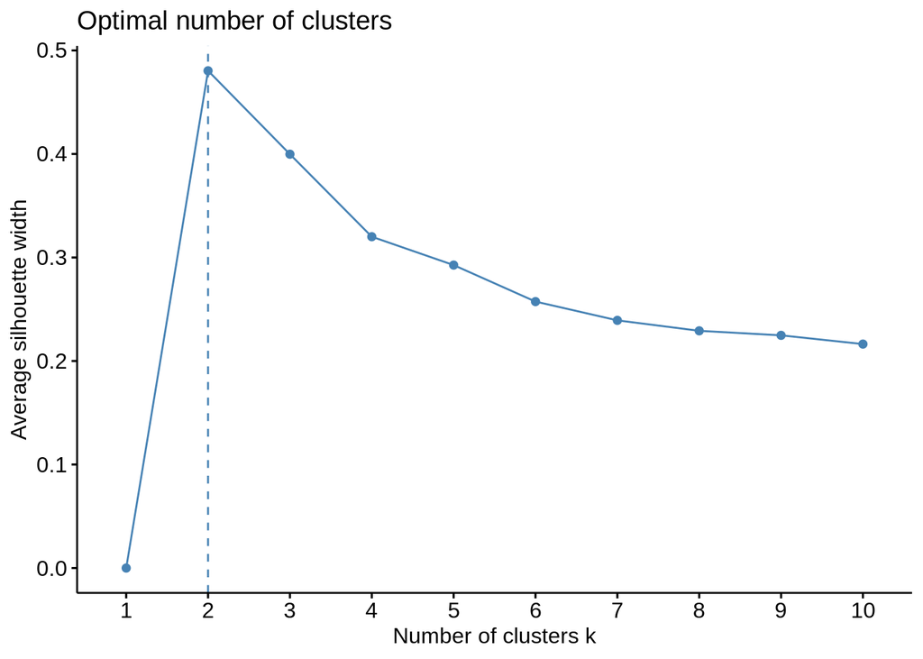

```r
# sillhouette method dan plotnya
siluet = fviz_nbclust(df_final, kmeans, method = "silhouette")
plot(siluet)
```

Dari *plot* di atas didapatkan bahwa $k = 2$.

## *Gap Stat Method*

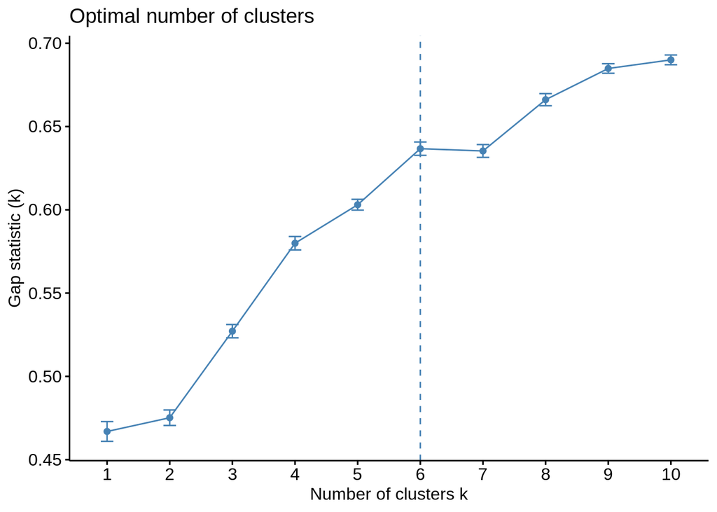

```r
# gap stat method dan plotnya
gap_stat = clusGap(df_final, FUN = kmeans, nstart = 10,K.max = 10, B = 10)
gap = fviz_gap_stat(gap_stat)
plot(gap)
```

Dari *plot* di atas didapatkan bahwa $k = 6$.

## Kesimpulan Nilai $k$

Kita akan coba membuat *k-Means clustering* saat nilai $k = 2,3,6$.

```r
# k-means clustering
kmeans_2 = kmeans(df_final, 2, nstart = 25)
kmeans_3 = kmeans(df_final, 3, nstart = 25)
kmeans_6 = kmeans(df_final, 6, nstart = 25)

# save hasil cluster ke data awal
df_final$k_means_2 = kmeans_2$cluster
df_final$k_means_3 = kmeans_3$cluster
df_final$k_means_6 = kmeans_6$cluster
```

### Hasil $k=2$

```r
# center dari masing-masing cluster
kmeans_2$centers
```

```
##   traffic_toko_jumlah_pengunjung_per_jam apakah_toko_memiliki_chiller
## 1                              0.8655942                    0.9782045
## 2                              0.2636054                    0.6896259
##   apakah_toko_memiliki_freezer_ice_cream
## 1                              0.9216399
## 2                              0.4557823
##   apakah_pengunjung_mengambil_barang_sendiri_swalayan jumlah_lorong
## 1                                           0.9564089      2.193565
## 2                                           0.6105442      0.630102
##   apakah_ada_keranjang_belanja apakah_toko_merupakan_mitra jumlah_kasir_toko
## 1                    0.9003633                   0.3144785         1.6232486
## 2                    0.2644558                   0.1938776         0.8562925
##   jumlah_pegawai
## 1       2.800727
## 2       1.612245
##   dropsize_customer_rata_rata_jumlah_uang_yang_dibelanjakan_pembeli_rp_customer
## 1                                                                     1.3518422
## 2                                                                     0.6785714
##       total
## 1 12.906072
## 2  6.255102
```

```r
# berapa banyak isi dari cluster
table(df_final$k_means_2)
```

```
##
##    1    2
## 1927 1176
```

### Hasil $k=3$

```r
# center dari masing-masing cluster
kmeans_3$centers
```

```
##   traffic_toko_jumlah_pengunjung_per_jam apakah_toko_memiliki_chiller
## 1                              1.0354559                    0.9811867
## 2                              0.3822785                    0.9291139
## 3                              0.1753731                    0.4458955
##   apakah_toko_memiliki_freezer_ice_cream
## 1                              0.9471780
## 2                              0.7518987
## 3                              0.2089552
##   apakah_pengunjung_mengambil_barang_sendiri_swalayan jumlah_lorong
## 1                                           0.9696093     2.4218524
## 2                                           0.8599156     1.2717300
## 3                                           0.3768657     0.2126866
##   apakah_ada_keranjang_belanja apakah_toko_merupakan_mitra jumlah_kasir_toko
## 1                   0.94934877                   0.3328509         1.8104197
## 2                   0.60084388                   0.2599156         1.0700422
## 3                   0.04104478                   0.1231343         0.6809701
##   jumlah_pegawai
## 1       2.892185
## 2       2.263291
## 3       1.145522
##   dropsize_customer_rata_rata_jumlah_uang_yang_dibelanjakan_pembeli_rp_customer
## 1                                                                     1.4985528
## 2                                                                     0.8793249
## 3                                                                     0.5410448
##       total
## 1 13.838640
## 2  9.268354
## 3  3.951493
```

```r
# berapa banyak isi dari cluster
table(df_final$k_means_3)
```

```
##
##    1    2    3
## 1382 1185  536
```

### Hasil $k=6$

```r
# center dari masing-masing cluster
kmeans_6$centers
```

```
##   traffic_toko_jumlah_pengunjung_per_jam apakah_toko_memiliki_chiller
## 1                              0.5796178                    0.9761146
## 2                              0.2389163                    0.7290640
## 3                              0.8957346                    0.9778831
## 4                              0.3904110                    0.9273973
## 5                              1.5166667                    0.9904762
## 6                              0.0979021                    0.2622378
##   apakah_toko_memiliki_freezer_ice_cream
## 1                             0.91719745
## 2                             0.44088670
## 3                             0.94154818
## 4                             0.72602740
## 5                             0.96428571
## 6                             0.09090909
##   apakah_pengunjung_mengambil_barang_sendiri_swalayan jumlah_lorong
```

[output cut: 34 more lines]

```r
# berapa banyak isi dari cluster
table(df_final$k_means_6)
```

```
##
##   1   2   3   4   5   6
## 628 406 633 730 420 286
```

## *Export* Hasil *K-Means Clustering*

Terlampir dalam *file* yang saya beri nama `kmeans.xlsx`.

```r
df_final %>% openxlsx::write.xlsx(file = "kmeans.xlsx")
```

# *Hierarchical clustering*

Berikut ini adalah pembuatan *hierarchical clustering*.

```r
# kita hanya akan pilih data numerik saja
# mengulang proses karena df_final sebelumnya sudah ada campuran k-means
df_final = df %>% select(where(is.numeric))

# Finding distance matrix
distance_mat = dist(df_final, method = 'euclidean')

# Fitting Hierarchical clustering Model
set.seed(240)  # Setting seed
Hierar_cl = hclust(distance_mat, method = "average")
Hierar_cl
```

```
##
## Call:
## hclust(d = distance_mat, method = "average")
##
## Cluster method   : average
## Distance         : euclidean
## Number of objects: 3103
```

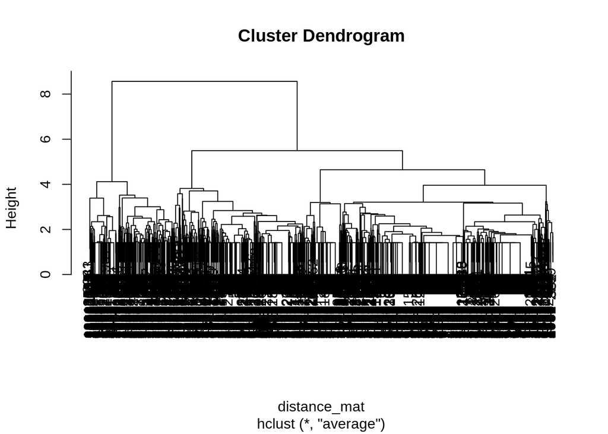

```r
# Plotting dendrogram
plot(Hierar_cl)
```

Saya akan pecah dendogram di atas menjadi 6 cluster utama.

```r
# Pemecahan menjadi 6 cluster
fit = cutree(Hierar_cl, k = 6)
plot(Hierar_cl)
table(fit)
```

```
## fit
##    1    2    3    4    5    6
##  367  876 1360  193   51  256
```

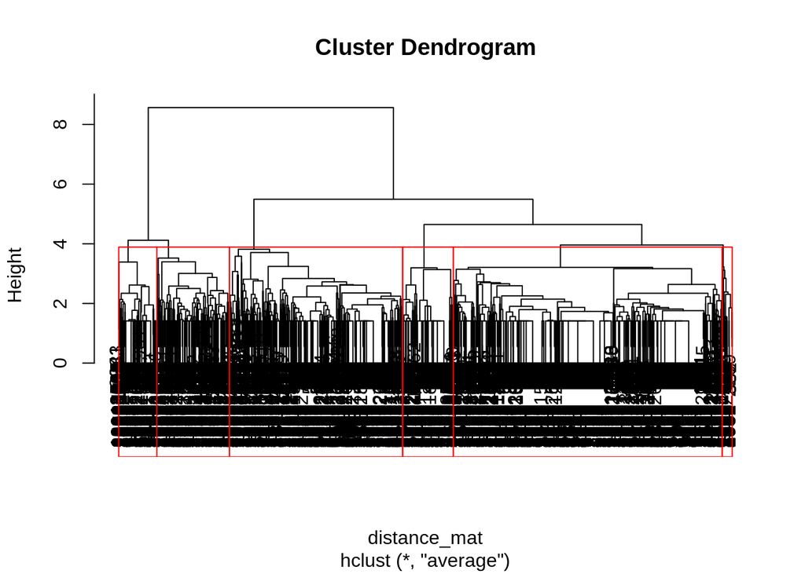

```r
rect.hclust(Hierar_cl, k = 6, border = "red")
```

```r
# save hasil cluster ke data awal
df_final$hi_cluster = fit
```

## *Export* Hasil *Hierarchical Clustering*

Terlampir dalam *file* yang saya beri nama `hier.xlsx`.

```r
df_final %>% openxlsx::write.xlsx(file = "hier.xlsx")
```

# *DBScan Clustering*

Berikut adalah hasil *clustering* dengan menggunakan metode *DBScan*. Salah satu langkah yang perlu dilakukan adalah menentukan nilai $eps$ yang paling optimal.

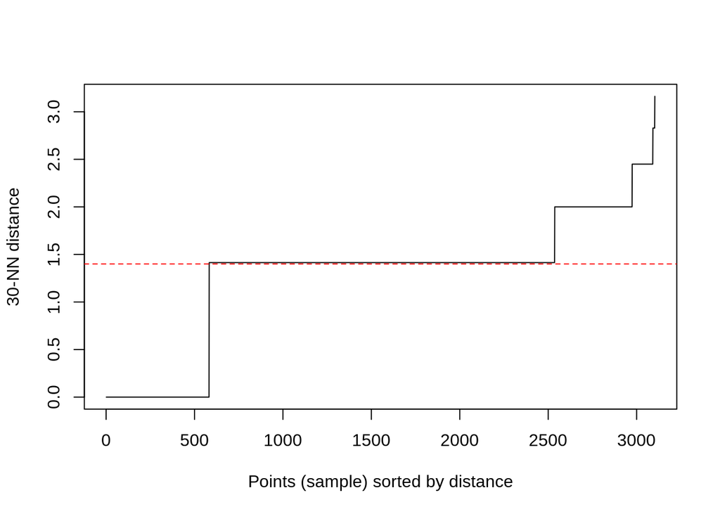

```r
# kita hanya akan pilih data numerik saja
# mengulang proses karena df_final sebelumnya sudah ada campuran k-means
data_cl = df %>% select(where(is.numeric))

dbscan::kNNdistplot(data_cl, k = 30)
abline(h = 1.4, lty = 2, col = "red")
```

```r
# memanggil libraries
library(fpc)
library(dbscan)
# membuat clustering DBScan
# set sed agar reproducible
set.seed(20921004)
Dbscan_cl = dbscan(data_cl, eps = 0.35, minPts = 5)

# menambahkan cluster ke dalam dataset
data_cl$cluster = Dbscan_cl$cluster

# menghitung ada berapa banyak cluster yang ada
data_cl$cluster %>% unique() %>% length()
```

```
## [1] 140
```

Tercatat ada **140** buah *cluster* yang terbentuk.

## *Export* Hasil *DBScan Clustering*

Terlampir dalam *file* yang saya beri nama `dbs.xlsx`.

```r
data_cl %>% openxlsx::write.xlsx(file = "dbs.xlsx")
```